# Visualizing Genomics Data in Bioconductor exercises

Tom Carroll

In this practical we will be reviewing some of methods for visualising and clustering data from ChIPseq data.

# Data

In todays session we will continue to review the Myc ChIPseq we were working on in our last sessions.

This include Myc ChIP-seq for MEL and Ch12 celllines.

Information and files for the [Myc ChIPseq in MEL cell line can be found here](https://www.encodeproject.org/experiments/ENCSR000EUA/)

Information and files for the [Myc ChIPseq in Ch12 cell line can be found here](https://www.encodeproject.org/experiments/ENCSR000ERN/)

BigWig for Mel cellline is [here](https://www.encodeproject.org/files/ENCFF388ZJX/@@download/ENCFF388ZJX.bigWig) ,Peaks for Mel cellline is [here](https://www.encodeproject.org/files/ENCFF591LSO/@@download/ENCFF591LSO.bed.gz) ,BAM for Mel cellline is [here](https://www.encodeproject.org/files/ENCFF049TYL/@@download/ENCFF049TYL.bam)

BigWig for Ch12 cellline is [here](https://www.encodeproject.org/files/ENCFF259VHD/@@download/ENCFF259VHD.bigWig) ,Peaks for Ch12 cellline is [here](https://www.encodeproject.org/files/ENCFF994LFX/@@download/ENCFF994LFX.bed.gz) ,BAM for Ch12 cellline is [here](https://www.encodeproject.org/files/ENCFF006JXP/@@download/ENCFF006JXP.bam)

- Create seperate profile plots for both Mel and Ch12 Myc signal over their respective Myc peaks. If you have troubles with memory you can try importing from BAM.

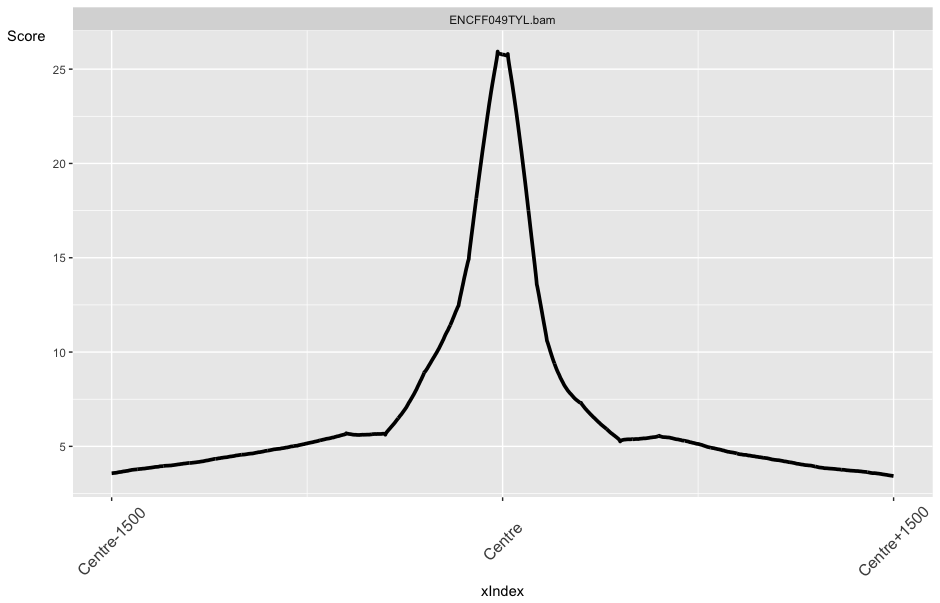

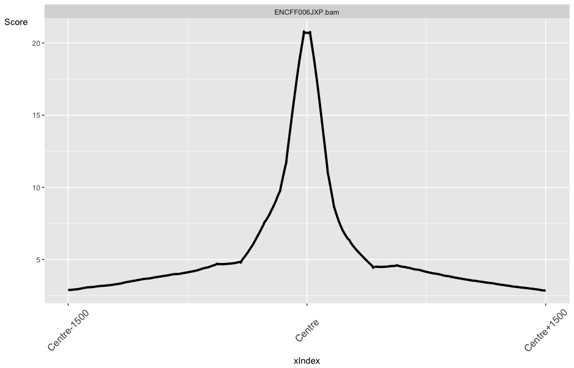

- Produce heatmaps for peaks on chr19 for each sample.

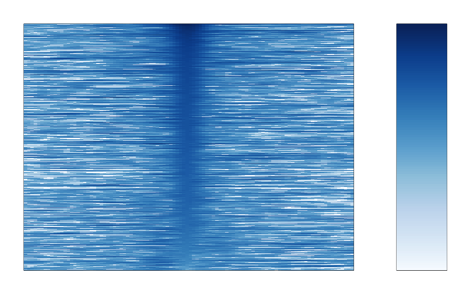

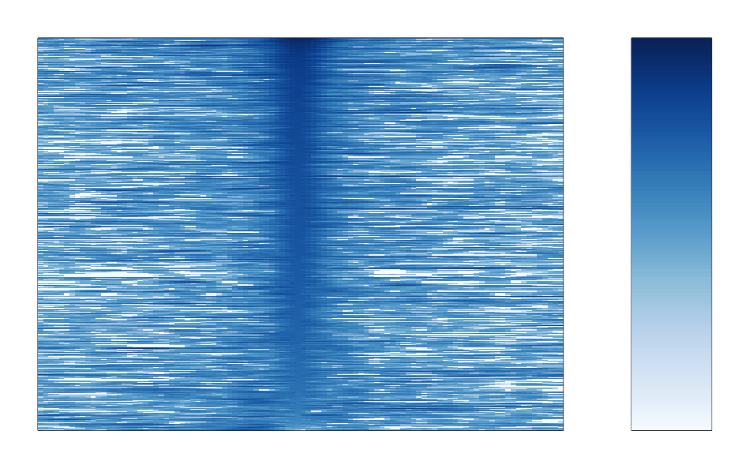

- for the Mel sample plot the profile of peaks overlapping and not overlapping Ch12 peaks.

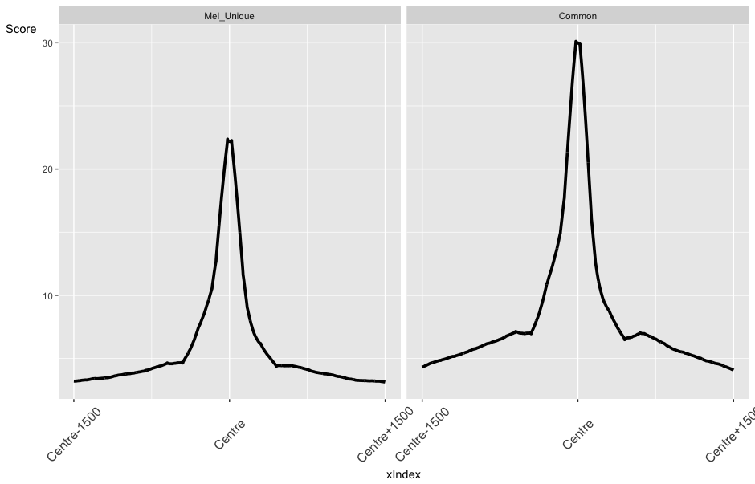

[figure not shown]

- Make a new profile plot of the Mel and Ch12 signal over our previously defined common peaks.

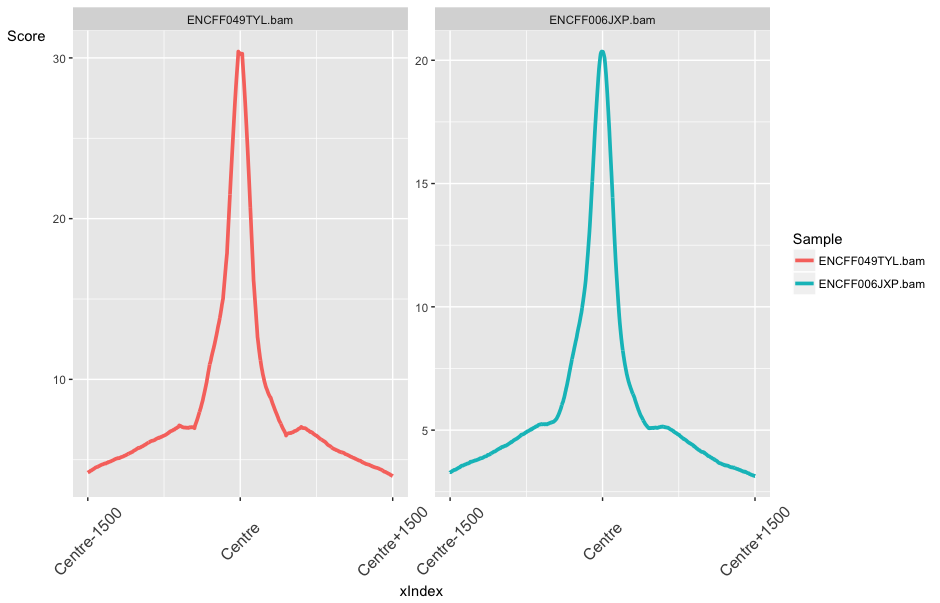